# Sprawozdanie 5

Andrzej Miczek, Jakub Laszczyk

2023.11.10

# **1.Wykorzystanie algorytmu SVM do predykcji wartości zmiennej wynikowej.**

**Wczytanie bibliotek**

```r
library(caret)
library(class)
```

**Wczytanie danych**

```r
dane <- read.csv("Heart2.csv", sep=";")
```

**Podział danych**

```r
str(dane)
```

```
## 'data.frame':    818 obs. of  16 variables:
##  $ Age             : int  40 49 37 48 54 39 45 54 48 37 ...
##  $ Sex             : int  1 0 1 0 1 1 0 1 0 0 ...
##  $ RestingBP       : int  140 160 130 138 150 120 130 110 120 130 ...
##  $ Cholesterol     : int  289 180 283 214 195 339 237 208 284 211 ...
##  $ FastingBS       : int  0 0 0 0 0 0 0 0 0 0 ...
##  $ MaxHR           : int  172 156 98 108 122 170 170 142 120 142 ...
##  $ ExerciseAngina  : int  1 1 1 0 1 1 1 1 1 1 ...
##  $ Oldpeak         : num  0 1 0 1.5 0 0 0 0 0 0 ...
##  $ ChestPainTypeASY: int  0 0 0 1 0 0 0 0 0 0 ...
##  $ ChestPainTypeATA: int  1 0 1 0 0 0 1 1 1 0 ...
##  $ ChestPainTypeNAP: int  0 1 0 0 1 1 0 0 0 1 ...
##  $ RestingECGLVH   : int  0 0 0 0 0 0 0 0 0 0 ...
##  $ RestingECGNormal: int  1 1 0 1 1 1 1 1 1 1 ...
##  $ STSlopeDown     : int  0 0 0 0 0 0 0 0 0 0 ...
##  $ STSlopeFlat     : int  0 1 0 1 0 0 0 0 0 0 ...
##  $ heartDisease    : int  0 1 0 1 0 0 0 0 0 0 ...
```

```r
dane[,c(1,3,4,6,8)] <- scale(dane[,c(1,3,4,6,8)])
dane$heartDisease <- as.factor(dane$heartDisease)
set.seed(123)
ind <- sample(2, nrow(dane), replace = TRUE, prob = c(0.7, 0.3))
train_set <- dane[ind==1,]
test_set <- dane[ind==2,]
train_control <- trainControl(method="repeatedcv", number=10, repeats=3)
```

# **a) jądro liniowe (linear)**

**Budowa modelu wykorzystującego jądro liniowe (linear)**

```r
#svm  jądro liniowe
svm_linear <- train(heartDisease~.,train_set,method ="svmLinear",
                    trControl= train_control,tuneLength =10)
svm_linear$bestTune
```

```
##   C
## 1 1
```

```r
#predykcja na zbiorze treningowym
pred1 <- predict(svm_linear,train_set)
confusionMatrix(pred1,train_set$heartDisease)
```

```
## Confusion Matrix and Statistics
##
##           Reference
## Prediction   0   1
##          0 257  36
##          1  35 248
##
##                Accuracy : 0.8767
##                  95% CI : (0.8471, 0.9025)
##     No Information Rate : 0.5069
##     P-Value [Acc > NIR] : <2e-16
##
##                   Kappa : 0.7534
##
##  Mcnemar's Test P-Value : 1
##
##             Sensitivity : 0.8801
##             Specificity : 0.8732
##          Pos Pred Value : 0.8771
##          Neg Pred Value : 0.8763
##              Prevalence : 0.5069
##          Detection Rate : 0.4462
##    Detection Prevalence : 0.5087
##       Balanced Accuracy : 0.8767
##
##        'Positive' Class : 0
##
```

```r
#predykcja na zbiorze testowym
pred2 <- predict(svm_linear,test_set)
matrix_linear <- confusionMatrix(pred2,test_set$heartDisease)
```

najlepsze wyniki otrzymano dla C = 1 **Przedstawienie hiperparametrów, które można optymalizować przy jądrze liniowy oraz wyjaśnienie za co odpowiadają** W jądrze liniowym SVM istnieje tylko jeden parametr - koszt (C). Oznacza to koszt błędnego zaklasyfikowania danych treningowych.

Duże C prowadzi do niskiego obciążenia (bias) i wysokiej wariancji. Niskie obciążenie wynika z tego, że kara za błędne zaklasyfikowanie jest wysoka. Duże C sprawia, że koszt błędnej klasyfikacji jest wysoki, co zmusza algorytm do dokładniejszego dopasowania do danych wejściowych i potencjalnie prowadzi do nadmiernego dopasowania (overfitting).

Małe C prowadzi do wyższego obciążenia i niższej wariancji. Małe C oznacza niski koszt błędnej klasyfikacji, co pozwala na więcej błędów dla uzyskania szerszego “poduszki” (cushion) czyli marginesu bezpieczeństwa wokół granicy decyzyjnej.

**Weryfikacja jak zmiana tych hiperparametrów wpływa na uzyskiwane wyniki**

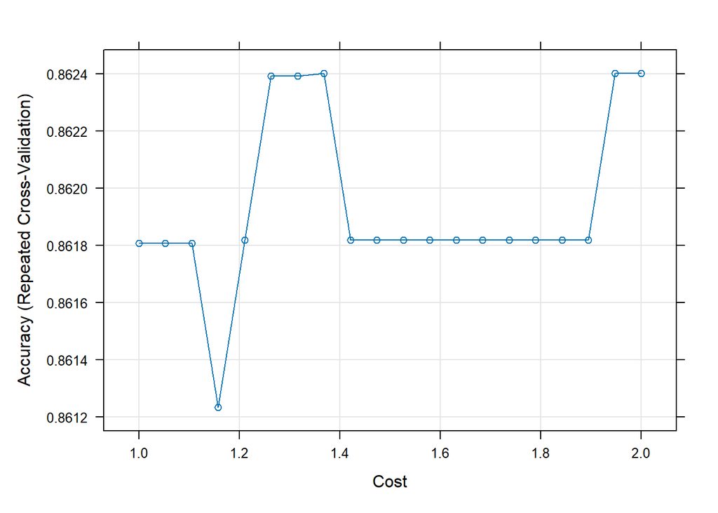

```r
#dobor parametru c
svm_grid <- train(heartDisease~.,
                    train_set,
                    method ="svmLinear",
                    trControl= train_control,
                    tuneGrid = expand.grid(C = seq(001, 2, length = 20))
                    #preProcess = c("center", "scale")
                    )
plot(svm_grid)
```

```r
svm_grid$bestTune
```

```
##          C
## 8 1.368421
```

```r
test_predgrid <- predict(svm_grid,test_set)
confusionMatrix(test_predgrid,test_set$heartDisease)
```

```
## Confusion Matrix and Statistics
##
##           Reference
## Prediction   0   1
##          0  99  16
##          1  19 108
##
##                Accuracy : 0.8554
##                  95% CI : (0.8046, 0.8971)
##     No Information Rate : 0.5124
##     P-Value [Acc > NIR] : <2e-16
##
##                   Kappa : 0.7104
##
##  Mcnemar's Test P-Value : 0.7353
##
##             Sensitivity : 0.8390
##             Specificity : 0.8710
##          Pos Pred Value : 0.8609
##          Neg Pred Value : 0.8504
##              Prevalence : 0.4876
##          Detection Rate : 0.4091
##    Detection Prevalence : 0.4752
##       Balanced Accuracy : 0.8550
##
##        'Positive' Class : 0
##
```

na wykresie możemy zobaczyc zależność miedzy kosztem, a dokładnościa naszego modelu. Do pewnego momentu wraz ze wzrostem c zwieksza sie dokladnosc, jednak nie sa to duze roznice.

# **b) jądro wielomianowe (poly)**

**Budowa modelu wykorzystującego jądro wielomianowe (poly)**

```r
#jądro wielomianowe
svm_Poly <- train(heartDisease~.,train_set,method ="svmPoly",
                    trControl= train_control,tuneLength =3)

svm_Poly$bestTune
```

```
##    degree scale C
## 24      3  0.01 1
```

```r
#predykcja na zbiorze treningowym
pred1 <- predict(svm_Poly,train_set)
confusionMatrix(pred1,train_set$heartDisease)
```

```
## Confusion Matrix and Statistics
##
##           Reference
## Prediction   0   1
##          0 257  32
##          1  35 252
##
##                Accuracy : 0.8837
##                  95% CI : (0.8546, 0.9087)
##     No Information Rate : 0.5069
##     P-Value [Acc > NIR] : <2e-16
##
##                   Kappa : 0.7673
##
##  Mcnemar's Test P-Value : 0.807
##
##             Sensitivity : 0.8801
##             Specificity : 0.8873
##          Pos Pred Value : 0.8893
##          Neg Pred Value : 0.8780
##              Prevalence : 0.5069
##          Detection Rate : 0.4462
##    Detection Prevalence : 0.5017
##       Balanced Accuracy : 0.8837
##
##        'Positive' Class : 0
##
```

```r
#predykcja na zbiorze testowym
pred2 <- predict(svm_Poly,test_set)
matrix_Poly <- confusionMatrix(pred2,test_set$heartDisease)
```

najlepsze wyniki otrzymano dla degree = 3 scale = 0.01 oraz c = 1. W tym przypadku tuneLength zostało zmniejszone do 3 poniewaz przy wiekszej liczbie czas uczenia był bardzo długi, można podejrzewac ze przy wyzszej wartosci zostałyby osiagniete lepsze wyniki. **Przedstawienie hiperparametrów, które można optymalizować przy jądrze liniowy oraz wyjaśnienie za co odpowiadają** C jak wczesniej Degree (Stopień wielomianu): Stopień wielomianu określa stopień używanego wielomianu w funkcji jądra. W przypadku jądra wielomianowego, dane są mapowane do przestrzeni wielowymiarowej za pomocą wielomianu o określonym stopniu. Stopień ten wpływa na to, jak bardzo złożony będzie model. Wyższe stopnie mogą prowadzić do bardziej skomplikowanych granic decyzyjnych, ale mogą także zwiększać ryzyko nadmiernego dopasowania. Wartość domyślna to zazwyczaj 3.

Scale (Skala): Skala jest używana w jądrze wielomianowym do kontrolowania skali cech. Skala wpływa na to, jak bardzo dane są przeskalowane przed zastosowaniem funkcji jądra wielomianowego. Odpowiednie dostosowanie skali może być istotne, zwłaszcza gdy różne cechy mają różne zakresy wartości. Domyślna wartość zazwyczaj wynosi 1.

**Weryfikacja jak zmiana tych hiperparametrów wpływa na uzyskiwane wyniki** #dobor parametrów

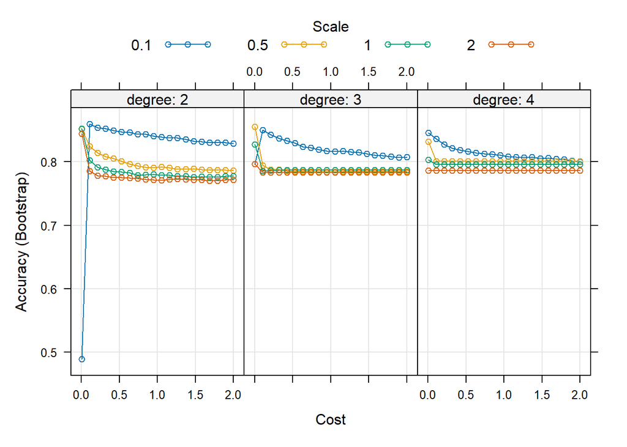

```r
svm_grid <- train(heartDisease~.,
                  train_set,
                  method ="svmPoly",
                  TrControl= train_control,
                  tuneGrid = expand.grid(
                  C = seq(0.001, 2, length = 20),
                  degree = c(2, 3, 4),
                  scale = c(0.1, 0.5, 1, 2)) #nie jestem pewien czy mozna tunowac ten
                  #parametr poniewaz odpowiada za scalowanie danych, a nasze dane posiadaja zmienne binarne których nie powinno sie scalowac
  #preProcess = c("center", "scale")
)

plot(svm_grid)
```

```r
svm_grid$bestTune
```

```
##    degree scale         C
## 13      2   0.1 0.1062105
```

```r
test_predgrid <- predict(svm_grid,test_set)
confusionMatrix(test_predgrid,test_set$heartDisease)
```

```
## Confusion Matrix and Statistics
##
##           Reference
## Prediction   0   1
##          0 100  13
##          1  18 111
##
##                Accuracy : 0.8719
##                  95% CI : (0.8231, 0.9113)
##     No Information Rate : 0.5124
##     P-Value [Acc > NIR] : <2e-16
##
##                   Kappa : 0.7434
##
##  Mcnemar's Test P-Value : 0.4725
##
##             Sensitivity : 0.8475
##             Specificity : 0.8952
##          Pos Pred Value : 0.8850
##          Neg Pred Value : 0.8605
##              Prevalence : 0.4876
##          Detection Rate : 0.4132
##    Detection Prevalence : 0.4669
##       Balanced Accuracy : 0.8713
##
##        'Positive' Class : 0
##
```

# **c) jądro radialne (rbf - radial basis function)**

**Budowa modelu wykorzystującego radialne (rbf - radial basis function)**

```r
#jądro radialne
svm_Radial <- train(heartDisease~.,train_set,method ="svmRadial",
                    trControl= train_control,tuneLength =10)

svm_Radial$bestTune
```

```
##        sigma   C
## 2 0.04729703 0.5
```

```r
#predykcja na zbiorze treningowym
pred1 <- predict(svm_Radial,train_set)
confusionMatrix(pred1,train_set$heartDisease)
```

```
## Confusion Matrix and Statistics
##
##           Reference
## Prediction   0   1
##          0 260  25
##          1  32 259
##
##                Accuracy : 0.901
##                  95% CI : (0.8737, 0.9242)
##     No Information Rate : 0.5069
##     P-Value [Acc > NIR] : <2e-16
##
##                   Kappa : 0.8021
##
##  Mcnemar's Test P-Value : 0.4268
##
##             Sensitivity : 0.8904
##             Specificity : 0.9120
##          Pos Pred Value : 0.9123
##          Neg Pred Value : 0.8900
##              Prevalence : 0.5069
##          Detection Rate : 0.4514
##    Detection Prevalence : 0.4948
##       Balanced Accuracy : 0.9012
##
##        'Positive' Class : 0
##
```

```r
#predykcja na zbiorze testowym
pred2 <- predict(svm_Radial,test_set)
matrix_radial <- confusionMatrix(pred2,test_set$heartDisease)
```

**Przedstawienie hiperparametrów, które można optymalizować przy jądrze liniowy oraz wyjaśnienie za co odpowiadają** C jak poprzednio. Sigma określa, jak daleko sięga wpływ pojedynczego przykładu treningowego. Gdy sigma jest bardzo małe, model jest zbyt ograniczony i nie jest w stanie uchwycić złożoności ani “kształtu” danych.

**Weryfikacja jak zmiana tych hiperparametrów wpływa na uzyskiwane wyniki**

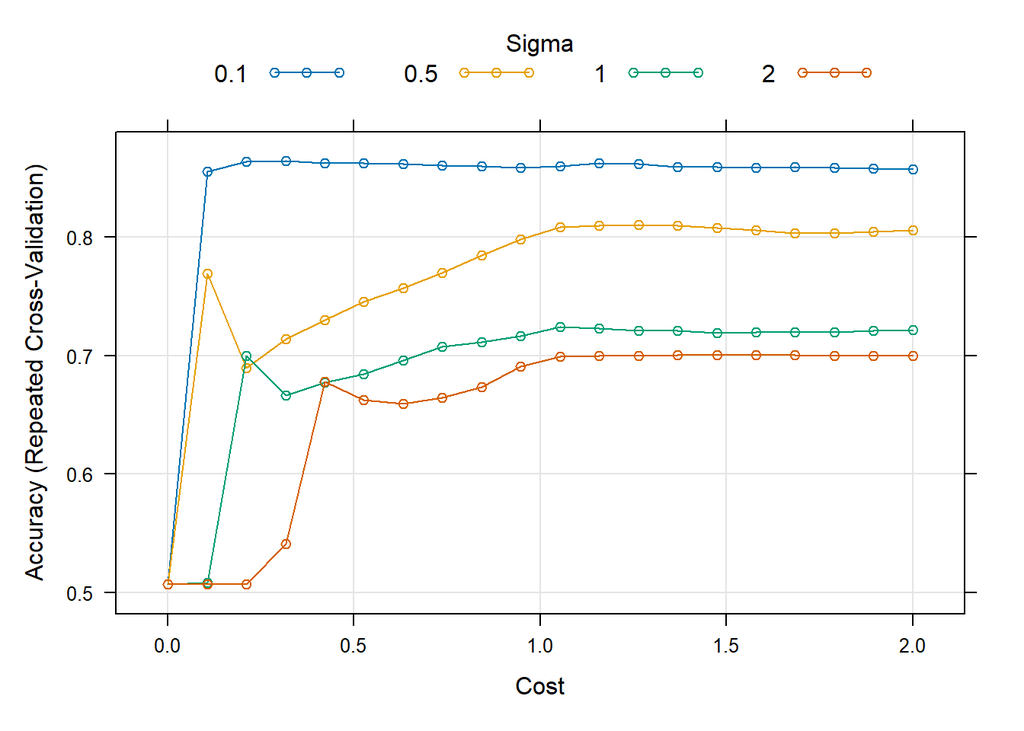

```r
#dobor parametru c  i sigma
svm_grid <- train(heartDisease~.,
                  train_set,
                  method ="svmRadial",
                  trControl= train_control,
                  tuneGrid = expand.grid(C = seq(0.001, 2, length = 20), sigma = c(0.1, 0.5, 1, 2))
                  #preProcess = c("center", "scale")
)

plot(svm_grid)
```

```r
svm_grid$bestTune
```

```
##    sigma         C
## 13   0.1 0.3166316
```

```r
test_predgrid <- predict(svm_grid,test_set)
confusionMatrix(test_predgrid,test_set$heartDisease)
```

```
## Confusion Matrix and Statistics
##
##           Reference
## Prediction   0   1
##          0 100  13
##          1  18 111
##
##                Accuracy : 0.8719
##                  95% CI : (0.8231, 0.9113)
##     No Information Rate : 0.5124
##     P-Value [Acc > NIR] : <2e-16
##
##                   Kappa : 0.7434
##
##  Mcnemar's Test P-Value : 0.4725
##
##             Sensitivity : 0.8475
##             Specificity : 0.8952
##          Pos Pred Value : 0.8850
##          Neg Pred Value : 0.8605
##              Prevalence : 0.4876
##          Detection Rate : 0.4132
##    Detection Prevalence : 0.4669
##       Balanced Accuracy : 0.8713
##
##        'Positive' Class : 0
##
```

Na wykresie widzimy zaleznosc miedzy c,sigma oraz dokładnościa. Najlepsze wyniki osiagnieto dla sigma = 0.1, dokladnosc na poczatku szybko rosła, a potem ustabilizowala sie wraz ze wzrostem c

# **d) Porównanie wyników uzyskanych w powyższych podpunktach. Wybór najlepszego modelu.**

```r
matrix_linear
```

```
## Confusion Matrix and Statistics
##
##           Reference
## Prediction   0   1
##          0  99  15
##          1  19 109
##
##                Accuracy : 0.8595
##                  95% CI : (0.8092, 0.9007)
##     No Information Rate : 0.5124
##     P-Value [Acc > NIR] : <2e-16
##
##                   Kappa : 0.7186
##
##  Mcnemar's Test P-Value : 0.6069
##
##             Sensitivity : 0.8390
##             Specificity : 0.8790
##          Pos Pred Value : 0.8684
##          Neg Pred Value : 0.8516
##              Prevalence : 0.4876
##          Detection Rate : 0.4091
##    Detection Prevalence : 0.4711
##       Balanced Accuracy : 0.8590
##
##        'Positive' Class : 0
##
```

```r
matrix_radial
```

```
## Confusion Matrix and Statistics
##
##           Reference
## Prediction   0   1
##          0 100  12
##          1  18 112
##
##                Accuracy : 0.876
##                  95% CI : (0.8278, 0.9148)
##     No Information Rate : 0.5124
##     P-Value [Acc > NIR] : <2e-16
##
##                   Kappa : 0.7516
##
##  Mcnemar's Test P-Value : 0.3613
##
##             Sensitivity : 0.8475
##             Specificity : 0.9032
##          Pos Pred Value : 0.8929
##          Neg Pred Value : 0.8615
##              Prevalence : 0.4876
##          Detection Rate : 0.4132
##    Detection Prevalence : 0.4628
##       Balanced Accuracy : 0.8753
##
##        'Positive' Class : 0
##
```

```r
matrix_Poly
```

```
## Confusion Matrix and Statistics
##
##           Reference
## Prediction   0   1
##          0 100  14
##          1  18 110
##
##                Accuracy : 0.8678
##                  95% CI : (0.8185, 0.9078)
##     No Information Rate : 0.5124
##     P-Value [Acc > NIR] : <2e-16
##
##                   Kappa : 0.7352
##
##  Mcnemar's Test P-Value : 0.5959
##
##             Sensitivity : 0.8475
##             Specificity : 0.8871
##          Pos Pred Value : 0.8772
##          Neg Pred Value : 0.8594
##              Prevalence : 0.4876
##          Detection Rate : 0.4132
##    Detection Prevalence : 0.4711
##       Balanced Accuracy : 0.8673
##
##        'Positive' Class : 0
##
```

# **Wykorzystanie dowolnego prostego model (np. KNN, KKNN lub regresję logistyczną) do predykcji wartości zmiennej wynikowej. Porównanie jakości klasyfikacji tego modelu z modelami wykorzystującymi algorytm SVM.**

```r
#model regresji logitycznej
formula <- heartDisease~.
model <- glm(formula , data = train_set, family = binomial)

# Predykcja na zbiorze testowym
predictions <- predict(model, test_set, type = 'response')

#Zamiana prawdopodobienstwa na 0 i 1
predicted_classes <- ifelse(predictions >= 0.5, 1,0)
predicted_classes <- as.factor(predicted_classes)
matrix_Regresja <- confusionMatrix(predicted_classes, test_set$heartDisease)
```

Porównanie

```r
wyniki <- data.frame(
  Model = c("Linear", "Radial", "Poly", "Regresja"),
  Accuracy = c(
    matrix_linear$overall[1],
    matrix_radial$overall[1],
    matrix_Poly$overall[1],
    matrix_Regresja$overall[1]
  ),
  Specificity = c(
    matrix_linear$byClass[2],
    matrix_radial$byClass[2],
    matrix_Poly$byClass[2],
    matrix_Regresja$byClass[2]
  )
)
wyniki
```

```
##      Model  Accuracy Specificity
## 1   Linear 0.8595041   0.8790323
## 2   Radial 0.8760331   0.9032258
## 3     Poly 0.8677686   0.8870968
## 4 Regresja 0.8719008   0.9032258
```

Model owykorzystujacy algorytm regresji logistycznej osiągnął minimalnie słabsze wyniki od modelu opartego na algorytmie svm wykorzystującym jądro radialne, był natomiast lepszy od modelu opartego na jadrze liniowym oraz jadrze wielomianowym.